# Exercise report on simple linear regression

Author

Mélanie FOURNIER

Published

September 3, 2024

```python
import numpy as np
import matplotlib.pyplot as plt
import pandas as pd
```

# Local simple regression

The goal of a local regression is to do a linear regression only a subset of samples with the observation $x_i$ that are close to a given value $x_0$.

The observations, denoted by $x_1,\dots x_k$ are also given a weight $w_i$, $i=1, \dots, k$ dependent on how close to $x_0$ the value is. That is the observations closest to $x_0$ are usually given a higher weight.

## Weighted least square.

The weighted least square problem is to find the parameter vector $\beta$ that minimizes the weighted least square problem

$$\hat{\beta} = \text{argmin}_\beta \sum_{i=1}^n w_i (y_i - (\beta_0 + \beta_1 x_1 + \dots \beta_p x_p))^2$$

The solution is given in (Canty):

$$\beta_0 = \bar{y_w} - \beta_1 \bar{x_w}$$

and

$$\beta_1 = \frac{\sum w_i(x-\bar{x}_w)(y_i-\bar{y}_w)}{\sum w_i(x-\bar{x}_w)^2},$$

where $\bar{x}_w$ and $\bar{y}_w$ are the weighted means of respectively the $x$ and the $y$ vectors. Setting all the weights to the same value yields on ordinary least square problem, for which the variance-covariance matrix for the estimator beta is given by: (Wasserman)

$$V[\hat{\beta}] = \hat{\sigma}^2(\mathbf{X}^T \mathbf{X})^{-1}$$

where $\mathbf{X}$ is the design matrix, and $\hat{\sigma}^2 = \frac{\sum e_i^2}{n-2}$ in the simple linear regression case. In the weighted case, this matrix has an expression that is a bit more complicated so this is not implemented in the code.

```python
def weighted_least_square(x,y,w):
    """
    Solve the simple weighted least square problem that minimizes
    sum w_i(y_i - beta_0 - beta_1 * x_i)^2

    w is the weight vector

    Returns the beta vector.
    """
    x_bar = np.average(x,weights=w)
    y_bar = np.average(y,weights=w)
    beta_1 = np.inner(w*(x-x_bar),y-y_bar) / np.inner(w*(x-x_bar),x-x_bar)
    beta_0 = y_bar - beta_1*x_bar
    beta = np.array([beta_0, beta_1])
    var_beta = None #TODO
    return beta, var_beta

def ols(x,y):
    """
    Perform the ordinary least square operation that minimizes
    sum w_i(y_i - beta_0 - beta_1 * x_i)^2.

    Return beta,and the associated variance-covariance matrix
    """
    x_bar = np.mean(x)
    y_bar = np.mean(y)
    beta_1 = np.inner((x-x_bar),y-y_bar) / np.inner((x-x_bar),x-x_bar)
    beta_0 = y_bar - beta_1 * x_bar
    beta = np.array([beta_0,beta_1])

    n = len(x)
    resid = y - beta_0 - beta_1 * x
    sigma_2 = 1/(n-2) * np.inner(resid,resid)

    X = np.vstack((np.ones(n),x)).T
    var_beta = sigma_2 * np.linalg.inv(X.T@X)
    return beta, var_beta
```

## Finding the nearest neighbours.

The following functions finds the indices of the k-nearest neighbours of the scalar $x_0$ in the vector $x$.

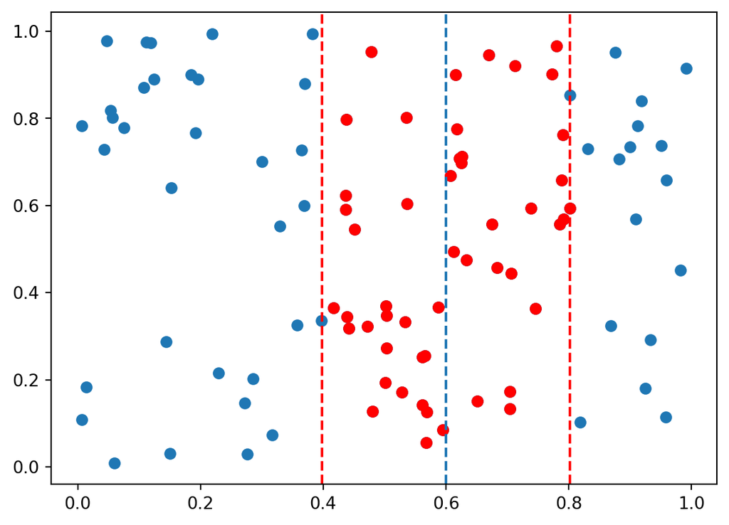

Testing of the function finding the k-th nearest neighbours of x0 (blue dashed line)

```python
def nearest_neighbour(x0,x,k):
    """
    Return the indices of the k-nearest points to x0, assuming 1d array
    """
    dist = np.abs(x-x0)
    dist_threshold = np.partition(dist,k-1)[k-1] #Get the value for the k'th lowest distance
    return dist <= dist_threshold , dist


np.random.seed(1234)
x = np.random.rand(100)
y = np.random.rand(100)

x0 = 0.6
k = 50

neighbours_idx , dist = nearest_neighbour(x0,x,k)
x_filtered = x[neighbours_idx]
y_filtered = y[neighbours_idx]


max_dist = np.max(np.abs(x_filtered-x0))


plt.scatter(x,y)
plt.scatter(x_filtered,y_filtered,color = 'red')
plt.axvline(x0, linestyle = '--')
plt.axvline(x0 + max_dist,color = 'red', linestyle = '--')
plt.axvline(x0 - max_dist,color = 'red', linestyle = '--')
```

We can now find the values of $\beta_0$ and $\beta_1$ that fit the weighted least square problem, considering only the k’th closest values of $x_0$.

```python
def loess(x0_vect,x,y,k,weight = 'constant'):
    """
    Calculate the local regression at the values given by x0
    Returns:
     - pred: the vector of predicted values
     - se: the vector of standard deviations for the expectation of the prediction
    """
    pred = np.zeros_like(x0_vect)
    se = np.zeros_like(x0_vect)
    for i, x0 in enumerate(x0_vect):
        nhb_idx , d_all = nearest_neighbour(x0,x,k)
        x_nhb = x[nhb_idx]
        y_nhb = y[nhb_idx]
        dist = d_all[nhb_idx] #Get the distance
        if weight == 'constant':
            beta, var_beta = ols(x_nhb,y_nhb)
        elif weight == 'tricube': #See wikipedia
            dist_sc = dist / np.max(dist)
            w = (1-dist_sc**3)**3
            beta , var_beta = weighted_least_square(x_nhb,y_nhb,w)
        else:
            raise NotImplementedError("Unknown or not implemented weigth method")
        #Get the estimation, and its estimated variance
        mu0 = beta[0] + beta[1]*x0
        if var_beta is None: #If the variance is not calculated
            pred[i] , se[i] = mu0 , None
        else:
            var_mu0 = var_beta[0,0] + var_beta[1,1]*x0**2+ 2*x0*var_beta[0,1] #Variance of $beta_0 + beta_1 x0$
            pred[i], se[i] = mu0, np.sqrt(var_mu0)
    return pred, se
```

The above can be tested on synthetic data.

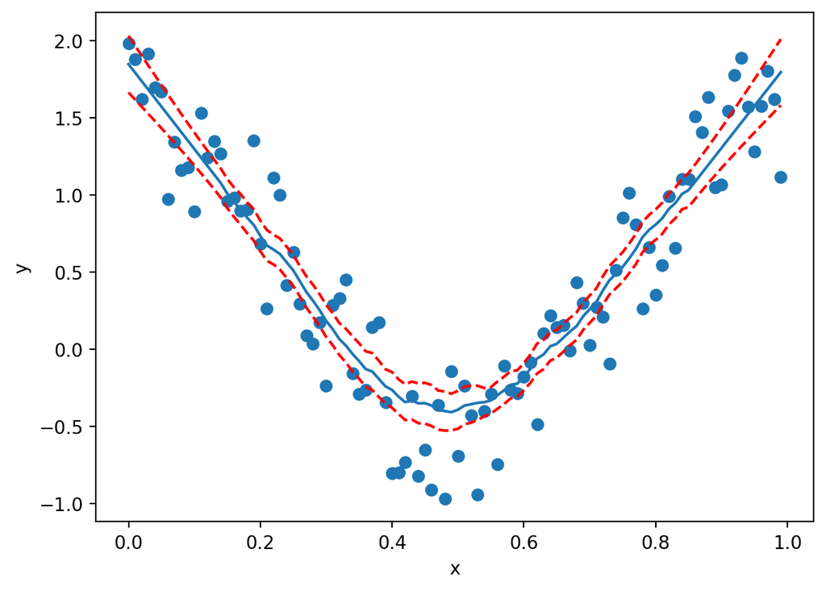

Loess smoothing (k=30) with synthetic data. The red line represent the 95% confidence interval on $E[\mu_0]$.

```python
x = np.arange(0,1,0.01)
y = np.random.rand(len(x)) + np.cos(2*np.pi*x)
k = 30 #Number of neighbours to consider

def plot_loess(x,y,k,xlab='x',ylab='y'):
    x_pred = np.linspace(np.min(x),np.max(x),100)
    y_pred = np.zeros_like(x_pred)
    var_pred = np.zeros_like(x_pred)
    y_pred, se_pred = loess(x_pred,x,y,k,weight='constant')
    plt.plot(x_pred,y_pred)
    #Plot the 95% C.I for the expected value
    plt.plot(x_pred,y_pred+1.96*se_pred,linestyle='--',color = 'red')
    plt.plot(x_pred,y_pred-1.96*se_pred,linestyle='--',color = 'red')
    plt.scatter(x,y)
    plt.xlabel(xlab)
    plt.ylabel(ylab)

plot_loess(x,y,k)
```

Choosing lower values of $k$ yields a less smooth fit with higher variance.

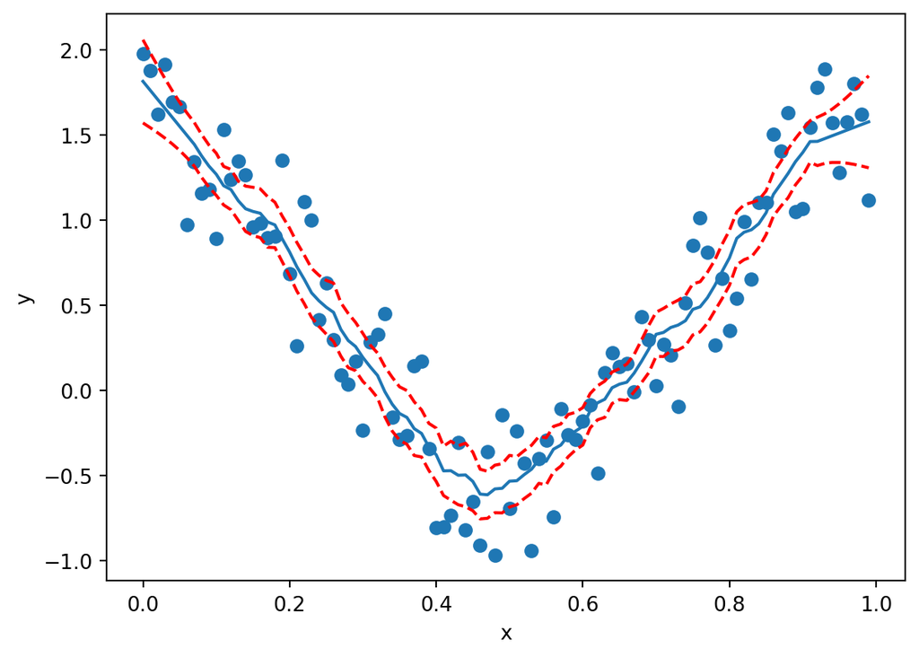

Loess smoothing (k=15) with synthetic data. The red line represent the 95% confidence interval on $E[\mu_0]$.

```python
k = 15
plot_loess(x,y,k)
```

# Application to Air polution data set.

The above functions can be applied to the Air pollution dataset. We only need the total age-adjusted mortality rate per 100,000 (MORT) and the % of families with income < $3000 (POOR) features

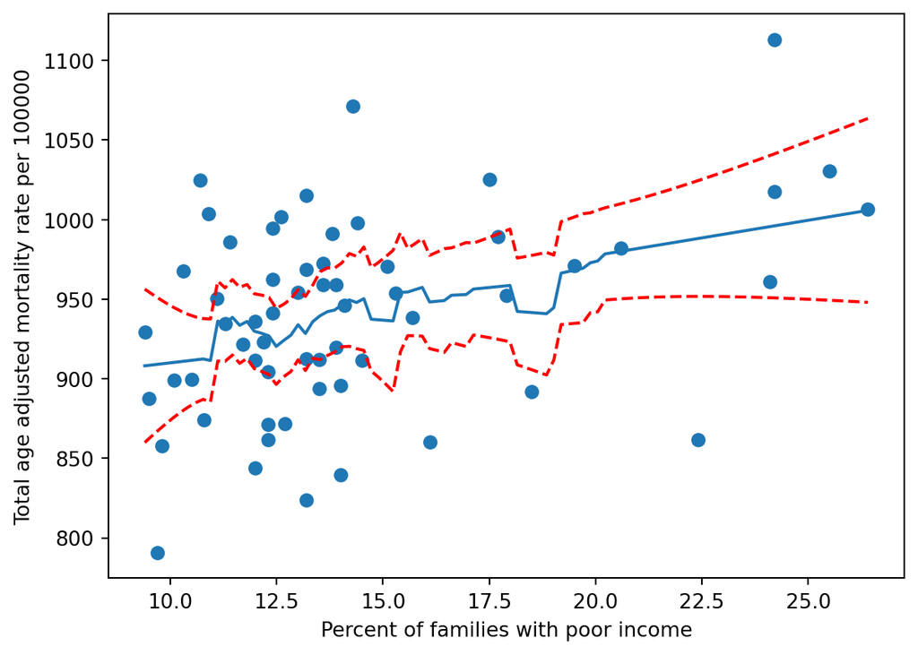

Loess smoothing (k=20) on the Air pollution dataset. The red line represent the 95% confidence interval on $E[\mu_0]$.

```python
df = pd.read_csv('pollution_cleaneddata.csv')
df2 = df[['MORT','POOR']]

x = df2['POOR'].to_numpy()
y = df2['MORT'].to_numpy()
k= 20

plot_loess(x,y,k,'Percent of families with poor income','Total age adjusted mortality rate per 100000')
```

In particular, a few predicted mortality rate for areas with 10, 18 and 25% of low income families are given below

```python
x0 = [10,18,25]

mu, se = loess(x0,x,y,k)

for i, x_0 in enumerate(x0):
    print(f'Predicted average mortality rate per 100k for areas with {x_0} percent of families having low income: {mu[i]}\n with standard error {se[i]}. 95% C.I [{-1.96*se[i]+mu[i]},{1.96*se[i]+mu[i]}]')
```

```
Predicted average mortality rate per 100k for areas with 10 percent of families having low income: 910
 with standard error 18. 95% C.I [874.72,945.28]
Predicted average mortality rate per 100k for areas with 18 percent of families having low income: 942
 with standard error 16. 95% C.I [910.64,973.36]
Predicted average mortality rate per 100k for areas with 25 percent of families having low income: 999
 with standard error 25. 95% C.I [950.0,1048.0]
```

In general, lower income areas experience a higher mortality rate.

Choosing a lower value of k makes for a more wiggly fit, we observe a bigger differente

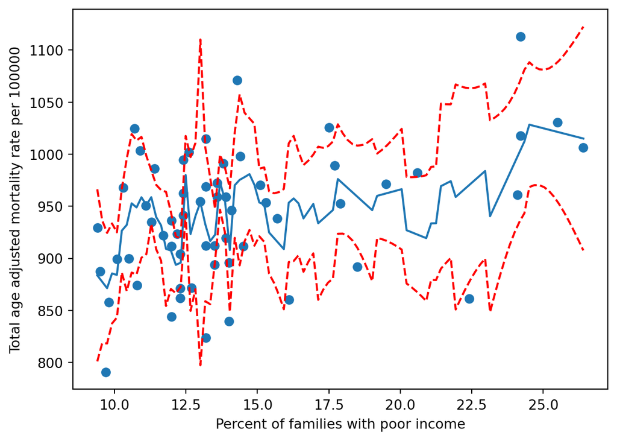

Loess smoothing (k=5) on the Air pollution dataset. The red line represent the 95% confidence interval on $E[\mu_0]$.

```python
df = pd.read_csv('pollution_cleaneddata.csv')
df2 = df[['MORT','POOR']]

x = df2['POOR'].to_numpy()
y = df2['MORT'].to_numpy()
k= 5

plot_loess(x,y,k,'Percent of families with poor income','Total age adjusted mortality rate per 100000')
```

```python
x0 = [10,18,25]

mu, se = loess(x0,x,y,k)

for i, x_0 in enumerate(x0):

    print(f'Predicted average mortality rate per 100k for areas with {x_0} percent of families having low income: {mu[i]}\n with standard error {se[i]}. 95% C.I [{-1.96*se[i]+mu[i]},{1.96*se[i]+mu[i]}]')
```

```
Predicted average mortality rate per 100k for areas with 10 percent of families having low income: 885
 with standard error 21. 95% C.I [843.84,926.16]
Predicted average mortality rate per 100k for areas with 18 percent of families having low income: 971
 with standard error 24. 95% C.I [923.96,1018.04]
Predicted average mortality rate per 100k for areas with 25 percent of families having low income: 1024
 with standard error 28. 95% C.I [969.12,1078.88]
```

## References

Canty, Angelo J. “Lecture Notes on Weighted Least Square.” https://ms.mcmaster.ca/canty/teaching/stat3a03/Lectures7.pdf.

Wasserman, Larry. “Modern Regression Lecture Notes.” https://www.stat.cmu.edu/~larry/=stat401/.